# Logbook Ramon Reilman transcriptomics

Ramon Reilman

2024-09-10

## Inleiding

### 13-11-2024

In dit logboek staat de verwerking van een transcriptomnics onderzoek. Het onderzoek bekijkt de impact van entinostat op de genexpressie tussen 2 verschillende soorten muizen.

## Quality controll

### 18-10-2024

De ruwe data is nu gedownload en uitgepakt, en we zullen eerst de kwaliteit moeten bepalen.

```bash
ls /students/2024-2025/Thema05/BlaasKanker/Transcriptomics/output/fastq/ | \
parallel "/students/2024-2025/Thema05/BlaasKanker/Transcriptomics/tools/bin/falco /students/2024-2025/Thema05/BlaasKanker/Transcriptomics/output/fastq/{} -o /students/2024-2025/Thema05/BlaasKanker/Transcriptomics/output/quality_control2/{}_fastqc_report"

multiqc /students/2024-2025/Thema05/BlaasKanker/Transcriptomics/output/quality_control2/* -o /students/2024-2025/Thema05/BlaasKanker/Transcriptomics/output/temp_multiqc
```

Nu kijken naar de door Iris getrimde data

```bash
ls /students/2024-2025/Thema05/BlaasKanker/Transcriptomics/output/quality_control/trimmomatic2 | grep -i -E "*_paired*" | \
parallel "/students/2024-2025/Thema05/BlaasKanker/Transcriptomics/tools/bin/falco /students/2024-2025/Thema05/BlaasKanker/Transcriptomics/output/quality_control/trimmomatic2/{} -o /students/2024-2025/Thema05/BlaasKanker/Transcriptomics/output/quality_control2/trimmed2/{}_fastqc_report"
```

Uiteindelijk is het gebleken dankzij Marcel dat de data niet getrimd hoeft te worden. STAR doet dit zelf al.

## Mapping

### 19-10-2024

We hebben 2 soorten cellen, muis en menselijk. De helft van onze samples hebben een muis cellen en de andere helft menselijke cellen. We gaan eerst de mapping doen tegen de muis cellen, die is geindexed door [Janine](https://github.com/RamonReilman/GenomicsTranscriptomics/blob/main/Transcriptomics/logbooks/JaninePostmus.Rmd)

```bash
cat /students/2024-2025/Thema05/BlaasKanker/Transcriptomics/mouse_cell_SRR.txt | \
    parallel 'STAR --runThreadN 6 ' \
        '--genomeDir /students/2024-2025/Thema05/BlaasKanker/Transcriptomics/tools/star/index_reference/ ' \
        '--readFilesIn /students/2024-2025/Thema05/BlaasKanker/Transcriptomics/output/fastq/{}_1.fastq /students/2024-2025/Thema05/BlaasKanker/Transcriptomics/output/fastq/{}_2.fastq ' \
        '--outSAMtype BAM SortedByCoordinate ' \
        '--quantMode GeneCounts ' \
        '--genomeLoad LoadAndRemove' \
        '--limitBAMsortRAM 2000000000 ' \
        '--outFileNamePrefix /students/2024-2025/Thema05/BlaasKanker/Transcriptomics/output/mapping/{}_star_'
```

Nu is de helft met de muis cellen gemapped tegen een muis referentie genoom. Na het mappen moet er gekeken worden of het mappen gelukt is:

```bash
multiqc --filename \
  /students/2024-2025/Thema05/BlaasKanker/Transcriptomics/output/sum_mapping/STAR-mapping1.html \
  /students/2024-2025/Thema05/BlaasKanker/Transcriptomics/output/mapping/
```

Hiervan zijn de resultaten goed, de mapping is succesvol.

```r
file.names <- list.files('/students/2024-2025/Thema05/BlaasKanker/Transcriptomics/output/mapping/',
                         pattern = '*_star_ReadsPerGene.out.tab')

## Function for reading in files
read_sample <- function(file.name) {
  ## Extract the sample name for naming the column (retaining the 'SRR....' part)
  sample.name <- strsplit(file.name, ".", fixed = TRUE)[[1]][1]
  sample <- read.table(file.name, header = FALSE, sep="\t",
                       row.names = NULL, skip = 4)
  ## Rename the count column
  names(sample)[2] <- sample.name
  ## Return a subset containing the transcript ID and sample name columns
  return(sample[c(1, 2)])
}
```

```r
setwd('/students/2024-2025/Thema05/BlaasKanker/Transcriptomics/output/mapping/')

## Read the FIRST sample
counts <- read_sample(file.names[1])

## Read the remaining files and merge the contents
for (file.name in file.names[2:length(file.names)]) {
  sample <- read_sample(file.name)
  counts <- merge(counts, sample, by = 1)
}

# Set the row names to the transcript IDs
rownames(counts) <- counts$V1
counts <- counts[-1]
head(counts)
```

```
##                    SRR12129014_star_ReadsPerGene SRR12129015_star_ReadsPerGene
## MissingGeneID                               5859                          4387
## gene-0610005C13Rik                             3                             0
## gene-0610006L08Rik                             0                             1
## gene-0610009E02Rik                             0                             1
## gene-0610009L18Rik                            53                            29
## gene-0610010K14Rik                          1024                           790
##                    SRR12129016_star_ReadsPerGene SRR12129017_star_ReadsPerGene
## MissingGeneID                               7820                          8707
## gene-0610005C13Rik                             0                             0
## gene-0610006L08Rik                             0                             0
## gene-0610009E02Rik                             1                             1
## gene-0610009L18Rik                            25                            93
## gene-0610010K14Rik                           881                          1408
##                    SRR12129018_star_ReadsPerGene SRR12129019_star_ReadsPerGene
## MissingGeneID                               3405                          3821
## gene-0610005C13Rik                             0                             0
## gene-0610006L08Rik                             0                             2
## gene-0610009E02Rik                             0                             1
## gene-0610009L18Rik                            43                            34
## gene-0610010K14Rik                           897                           523
##                    SRR12129020_star_ReadsPerGene SRR12129021_star_ReadsPerGene
## MissingGeneID                               3777                          6823
## gene-0610005C13Rik                             1                             0
## gene-0610006L08Rik                             0                             0
## gene-0610009E02Rik                             1                             4
## gene-0610009L18Rik                            44                            93
## gene-0610010K14Rik                           492                          1304
##                    SRR12129022_star_ReadsPerGene SRR12129023_star_ReadsPerGene
## MissingGeneID                               4673                          7162
## gene-0610005C13Rik                             0                             0
## gene-0610006L08Rik                             0                             0
## gene-0610009E02Rik                             0                             0
## gene-0610009L18Rik                            25                            55
## gene-0610010K14Rik                           975                          1390
##                    SRR12129024_star_ReadsPerGene SRR12129025_star_ReadsPerGene
## MissingGeneID                               2160                          5096
## gene-0610005C13Rik                             1                             0
## gene-0610006L08Rik                             1                             0
## gene-0610009E02Rik                             1                             0
```

[output cut: 57 more lines]

```
## gene-0610010K14Rik                           735                          1145
##                    SRR12129042_star_ReadsPerGene SRR12129043_star_ReadsPerGene
## MissingGeneID                               8495                          8854
## gene-0610005C13Rik                             2                             4
## gene-0610006L08Rik                             0                             0
## gene-0610009E02Rik                             5                             8
## gene-0610009L18Rik                           122                           150
## gene-0610010K14Rik                          1618                          1689
##                    SRR12129044_star_ReadsPerGene
## MissingGeneID                               7730
## gene-0610005C13Rik                             2
## gene-0610006L08Rik                             1
## gene-0610009E02Rik                             4
## gene-0610009L18Rik                           160
## gene-0610010K14Rik                          1511
```

```bash
blastn -query /students/2024-2025/Thema05/BlaasKanker/Transcriptomics/output/temp_fasta/SRR12129014_1.fasta -db nt -outfmt 6 -max_target_seqs 1 -num_threads 6 -out  /students/2024-2025/Thema05/BlaasKanker/Transcriptomics/output/blastn/results.out
```

Het blijken wel muis cellen te zijn. Een github issue geeft aan dat we wel een gtf bestand nodig hebben bij het indexen, niet een gff bestand zoals Marcel dat aangaf. Met het volgende command kan een gtf bestand gegenereerd worden.

```bash
gffread -E /students/2024-2025/Thema05/BlaasKanker/tools/testGenome/ncbi_dataset/data/GCF_000001635.27/genomic.gff -T -o  /students/2024-2025/Thema05/BlaasKanker/tools/testGenome/ncbi_dataset/data/GCF_000001635.27/genomic.gtf
```

Opnieuw een index genereren met een gtf bestand nu.

```bash
STAR --runThreadN 4 --runMode genomeGenerate --genomeDir /students/2024-2025/Thema05/BlaasKanker/Transcriptomics/tools/star/index_GRCm39 --genomeFastaFiles /students/2024-2025/Thema05/BlaasKanker/tools/testGenome/ncbi_dataset/data/GCF_000001635.27/GCF_000001635.27_GRCm39_genomic.fna --sjdbGTFfile /students/2024-2025/Thema05/BlaasKanker/tools/testGenome/ncbi_dataset/data/GCF_000001635.27/genomic.gtf --sjdbOverhang 75
```

Opnieuw de mapping uitvoeren met het juiste referentie genoom.

```bash
cat /students/2024-2025/Thema05/BlaasKanker/Transcriptomics/mouse_cell_SRR.txt | \
    parallel 'STAR --runThreadN 6 ' \
        '--genomeDir /students/2024-2025/Thema05/BlaasKanker/Transcriptomics/tools/star/index_GRCm39/ ' \
        '--readFilesIn /students/2024-2025/Thema05/BlaasKanker/Transcriptomics/output/fastq/{}_1.fastq /students/2024-2025/Thema05/BlaasKanker/Transcriptomics/output/fastq/{}_2.fastq ' \
        '--outSAMtype BAM SortedByCoordinate ' \
        '--quantMode GeneCounts ' \
        '--genomeLoad LoadAndRemove' \
        '--limitBAMsortRAM 2000000000 ' \
        '--outFileNamePrefix /students/2024-2025/Thema05/BlaasKanker/Transcriptomics/output/mapping/{}_star_'
```

Bepalen of de kwaliteit van de mapping goed is.

```bash
multiqc --filename \
  /students/2024-2025/Thema05/BlaasKanker/Transcriptomics/output/sum_mapping/STAR-mapping2.html \
  /students/2024-2025/Thema05/BlaasKanker/Transcriptomics/output/mapping/
```

voer ook nog even een blast uit op een nsg muis, om te kijken of hier menselijke cellen in zitten.

```bash
blastn -query /students/2024-2025/Thema05/BlaasKanker/Transcriptomics/output/temp_fasta/SRR12129031_1.fasta -db nt -outfmt 6 -max_target_seqs 1 -num_threads 10 -out  /students/2024-2025/Thema05/BlaasKanker/Transcriptomics/output/blastn/results_nsg.out
```

NSG muizen bevatten mogelijk wel menselijke cellen, dus die moet ook met star een index krijgen Genereer een gtf bestand voor het menselijke referentie genoom.

```bash
gffread -E /students/2024-2025/Thema05/BlaasKanker/Transcriptomics/tools/ref_genes/ncbi_dataset/data/GCF_000001405.40/genomic.gff -T -o  /students/2024-2025/Thema05/BlaasKanker/Transcriptomics/tools/ref_genes/ncbi_dataset/data/GCF_000001405.40/genomic.gtf
```

Maak een index voor STAR van het menselijke referentie genoom.

```bash
STAR --runThreadN 4 --runMode genomeGenerate --genomeDir /students/2024-2025/Thema05/BlaasKanker/Transcriptomics/tools/star/index_GRCh38 --genomeFastaFiles /students/2024-2025/Thema05/BlaasKanker/Transcriptomics/tools/ref_genes/ncbi_dataset/data/GCF_000001405.40/GCF_000001405.40_GRCh38.p14_genomic.fna --sjdbGTFfile /students/2024-2025/Thema05/BlaasKanker/Transcriptomics/tools/ref_genes/ncbi_dataset/data/GCF_000001405.40/genomic.gtf --sjdbOverhang 75
```

Mappen van de NSG muis tegen een menselijke referentie genoom.

```bash
cat /students/2024-2025/Thema05/BlaasKanker/Transcriptomics/nsg_mouse_SRR.txt | \
    parallel 'STAR --runThreadN 6 ' \
        '--genomeDir /students/2024-2025/Thema05/BlaasKanker/Transcriptomics/tools/star/index_GRCh38/ ' \
        '--readFilesIn /students/2024-2025/Thema05/BlaasKanker/Transcriptomics/output/fastq/{}_1.fastq /students/2024-2025/Thema05/BlaasKanker/Transcriptomics/output/fastq/{}_2.fastq ' \
        '--outSAMtype BAM SortedByCoordinate ' \
        '--quantMode GeneCounts ' \
        '--genomeLoad LoadAndRemove' \
        '--limitBAMsortRAM 2000000000 ' \
        '--outFileNamePrefix /students/2024-2025/Thema05/BlaasKanker/Transcriptomics/output/mapping/{}_star_'
```

Het mappen hiervan is niet goed gegaan, het is gebleken dat de NSG muis geen menselijke cellen heeft. Deze bestanden zijn opnieuw gemapped tegen het muis genoom.

```bash
cat /students/2024-2025/Thema05/BlaasKanker/Transcriptomics/nsg_mouse_SRR.txt | \
    parallel 'STAR --runThreadN 6 ' \
        '--genomeDir /students/2024-2025/Thema05/BlaasKanker/Transcriptomics/tools/star/index_GRCm39/ ' \
        '--readFilesIn /students/2024-2025/Thema05/BlaasKanker/Transcriptomics/output/fastq/{}_1.fastq /students/2024-2025/Thema05/BlaasKanker/Transcriptomics/output/fastq/{}_2.fastq ' \
        '--outSAMtype BAM SortedByCoordinate ' \
        '--quantMode GeneCounts ' \
        '--genomeLoad LoadAndRemove' \
        '--limitBAMsortRAM 2000000000 ' \
        '--outFileNamePrefix /students/2024-2025/Thema05/BlaasKanker/Transcriptomics/output/mapping/{}_mm39_star_'
```

## Deseq

#### 28-10

Deseq werkt niet helemaal bij Jannie omdat de rownames en colnames niet helemaal overeen komen. Tussen het info bestand en de count df

```r
col_data <- read.csv("/students/2024-2025/Thema05/BlaasKanker/etc/DSEQ_verwerking(Sheet1).csv", sep = ";")
rownames(col_data) <- col_data[,1]
```

## Annot count_data

Het annoteren van onze data zorgt ervoor dat de genen de NCBI naamgeving krijgen. Zo is het straks overzichtelijker om informatie te vinden over de genen.

```r
col_data <- col_data %>%
    dplyr::group_by(strain, treatment) %>%
    dplyr::mutate(r_num = row_number()) %>%
    dplyr::ungroup() %>%
    mutate(condition = paste0(strain, "_", treatment, "_r", r_num))
head(col_data)
```

```
## # A tibble: 6 × 6
##   Run                           source_name     strain treatment r_num condition
##   <chr>                         <chr>           <chr>  <chr>     <int> <chr>
## 1 SRR12129014_star_ReadsPerGene C57BL/6_bladde… C57BL… Vehicle       1 C57BL/6_…
## 2 SRR12129015_star_ReadsPerGene C57BL/6_bladde… C57BL… Entinost…     1 C57BL/6_…
## 3 SRR12129016_star_ReadsPerGene C57BL/6_bladde… C57BL… Vehicle       2 C57BL/6_…
## 4 SRR12129017_star_ReadsPerGene C57BL/6_bladde… C57BL… Vehicle       3 C57BL/6_…
## 5 SRR12129018_star_ReadsPerGene C57BL/6_bladde… C57BL… Vehicle       4 C57BL/6_…
## 6 SRR12129019_star_ReadsPerGene C57BL/6_bladde… C57BL… Entinost…     2 C57BL/6_…
```

In de bestanden kon niks gevonden worden over de genen, maar zo is het wel duidelijker waar elke kolom voor staat. Dat moet nu nog toegepast worden in de counts df

```r
for (i in 1:nrow(col_data)) {
  idx <- grep(col_data$Run[i], names(counts))
  names(counts)[idx] <- col_data$condition[i]
}
head(counts)
```

```
##                    C57BL/6_Vehicle_r1 C57BL/6_Entinostat_r1 C57BL/6_Vehicle_r2
## MissingGeneID                    5859                  4387               7820
## gene-0610005C13Rik                  3                     0                  0
## gene-0610006L08Rik                  0                     1                  0
## gene-0610009E02Rik                  0                     1                  1
## gene-0610009L18Rik                 53                    29                 25
## gene-0610010K14Rik               1024                   790                881
##                    C57BL/6_Vehicle_r3 C57BL/6_Vehicle_r4 C57BL/6_Entinostat_r2
## MissingGeneID                    8707               3405                  3821
## gene-0610005C13Rik                  0                  0                     0
## gene-0610006L08Rik                  0                  0                     2
## gene-0610009E02Rik                  1                  0                     1
## gene-0610009L18Rik                 93                 43                    34
## gene-0610010K14Rik               1408                897                   523
##                    C57BL/6_Entinostat_r3 C57BL/6_Vehicle_r5 C57BL/6_Baseline_r1
## MissingGeneID                       3777               6823                4673
## gene-0610005C13Rik                     1                  0                   0
## gene-0610006L08Rik                     0                  0                   0
## gene-0610009E02Rik                     1                  4                   0
## gene-0610009L18Rik                    44                 93                  25
## gene-0610010K14Rik                   492               1304                 975
##                    C57BL/6_Baseline_r2 C57BL/6_Entinostat_r4
## MissingGeneID                     7162                  2160
## gene-0610005C13Rik                   0                     1
## gene-0610006L08Rik                   0                     1
## gene-0610009E02Rik                   0                     1
## gene-0610009L18Rik                  55                    15
## gene-0610010K14Rik                1390                   419
##                    C57BL/6_Baseline_r3 C57BL/6_Entinostat_r5
## MissingGeneID                     5096                  2718
## gene-0610005C13Rik                   0                     0
## gene-0610006L08Rik                   0                     0
## gene-0610009E02Rik                   0                     4
## gene-0610009L18Rik                  24                    49
## gene-0610010K14Rik                 972                   676
##                    C57BL/6_Entinostat_r6 C57BL/6_Vehicle_r6 C57BL/6_Baseline_r4
## MissingGeneID                       3870               9562                5163
## gene-0610005C13Rik                     0                  0                   0
## gene-0610006L08Rik                     0                  0                   0
## gene-0610009E02Rik                     6                  0                   2
```

[output cut: 22 more lines]

```
## gene-0610010K14Rik              1528              1339               387
##                    NSG_Entinostat_r5 NSG_Vehicle_r1 NSG_Vehicle_r2
## MissingGeneID                  12470           5393           7122
## gene-0610005C13Rik                 2              2              1
## gene-0610006L08Rik                 1              0              0
## gene-0610009E02Rik                13              6             11
## gene-0610009L18Rik               113             41             50
## gene-0610010K14Rik              1393            735           1145
##                    NSG_Vehicle_r3 NSG_Vehicle_r4 NSG_Vehicle_r5
## MissingGeneID                8495           8854           7730
## gene-0610005C13Rik              2              4              2
## gene-0610006L08Rik              0              0              1
## gene-0610009E02Rik              5              8              4
## gene-0610009L18Rik            122            150            160
## gene-0610010K14Rik           1618           1689           1511
```

Nu zijn de SRR* namen vervangen met waar ze voor staan en is de df duidelijker te lezen, om straks makkelijker de kolommen op te halen die horen bij elk mogelijke variant groepeer ik deze.

Nu moeten we nog de namen van de genen veranderen naar iets wat meer leesbaar is. Dit moet handmatig gedaan worden omdat de GEO annot data niet genoeg info bevat.

```r
counts$Ensembl <- mapIds(x = org.Mm.eg.db,
                           keys=gsub("gene-", "",row.names(counts)),
                           column="ENSEMBL",
                           keytype="SYMBOL",
                           multiVals="first")
head(counts)
```

```
##                    C57BL/6_Vehicle_r1 C57BL/6_Entinostat_r1 C57BL/6_Vehicle_r2
## MissingGeneID                    5859                  4387               7820
## gene-0610005C13Rik                  3                     0                  0
## gene-0610006L08Rik                  0                     1                  0
## gene-0610009E02Rik                  0                     1                  1
## gene-0610009L18Rik                 53                    29                 25
## gene-0610010K14Rik               1024                   790                881
##                    C57BL/6_Vehicle_r3 C57BL/6_Vehicle_r4 C57BL/6_Entinostat_r2
## MissingGeneID                    8707               3405                  3821
## gene-0610005C13Rik                  0                  0                     0
## gene-0610006L08Rik                  0                  0                     2
## gene-0610009E02Rik                  1                  0                     1
## gene-0610009L18Rik                 93                 43                    34
## gene-0610010K14Rik               1408                897                   523
##                    C57BL/6_Entinostat_r3 C57BL/6_Vehicle_r5 C57BL/6_Baseline_r1
## MissingGeneID                       3777               6823                4673
## gene-0610005C13Rik                     1                  0                   0
## gene-0610006L08Rik                     0                  0                   0
## gene-0610009E02Rik                     1                  4                   0
## gene-0610009L18Rik                    44                 93                  25
## gene-0610010K14Rik                   492               1304                 975
##                    C57BL/6_Baseline_r2 C57BL/6_Entinostat_r4
## MissingGeneID                     7162                  2160
## gene-0610005C13Rik                   0                     1
## gene-0610006L08Rik                   0                     1
## gene-0610009E02Rik                   0                     1
## gene-0610009L18Rik                  55                    15
## gene-0610010K14Rik                1390                   419
##                    C57BL/6_Baseline_r3 C57BL/6_Entinostat_r5
## MissingGeneID                     5096                  2718
## gene-0610005C13Rik                   0                     0
## gene-0610006L08Rik                   0                     0
## gene-0610009E02Rik                   0                     4
## gene-0610009L18Rik                  24                    49
## gene-0610010K14Rik                 972                   676
##                    C57BL/6_Entinostat_r6 C57BL/6_Vehicle_r6 C57BL/6_Baseline_r4
## MissingGeneID                       3870               9562                5163
## gene-0610005C13Rik                     0                  0                   0
## gene-0610006L08Rik                     0                  0                   0
## gene-0610009E02Rik                     6                  0                   2
```

[output cut: 29 more lines]

```
## gene-0610010K14Rik              1393            735           1145
##                    NSG_Vehicle_r3 NSG_Vehicle_r4 NSG_Vehicle_r5
## MissingGeneID                8495           8854           7730
## gene-0610005C13Rik              2              4              2
## gene-0610006L08Rik              0              0              1
## gene-0610009E02Rik              5              8              4
## gene-0610009L18Rik            122            150            160
## gene-0610010K14Rik           1618           1689           1511
##                               Ensembl
## MissingGeneID                    <NA>
## gene-0610005C13Rik ENSMUSG00000085214
## gene-0610006L08Rik               <NA>
## gene-0610009E02Rik ENSMUSG00000086714
## gene-0610009L18Rik ENSMUSG00000043644
## gene-0610010K14Rik ENSMUSG00000020831
```

Om overige dingen aan te vullen ga ik ook nog gebruikt maken van biomaRt

```r
library(biomaRt)


ensembl <- useMart("ensembl")

mart.datasets <- listDatasets(ensembl)
ensembl <- useDataset('mmusculus_gene_ensembl', mart = ensembl)

filters <- listFilters(ensembl)

attributes <- listAttributes(ensembl)

attrs.get <- c("ensembl_gene_id", "chromosome_name",
               "start_position","end_position", "description")
non_na <- !is.na(counts$Ensembl)
# Perform a biomaRt query using 'getBM'
result <- getBM(attributes = attrs.get,
                 filters = "ensembl_gene_id",
                 values = counts$Ensembl[non_na],
                 mart = ensembl)
```

Dit werkt niet, en dus zal ik het zo laten.

```r
C57BL_Vehicle <- grep("C57BL/6_Vehicle", names(counts))
C57BL_Entinostat <- grep("C57BL/6_Entinostat", names(counts))
C57BL_Baseline <- grep("C57BL/6_Baseline", names(counts))

nsg_Vehicle <- grep("NSG_Vehicle", names(counts))
nsg_Entinostat <- grep("NSG_Entinostat", names(counts))
nsg_Baseline <- grep("NSG_Baseline", names(counts))
```

Nu kunnen deze variabelen gebruikt worden om de juiste kolommen te selecteren.

Dan kan dit nu samengevoegd worden met DESEQ, wat Jannie heeft uitgezocht. Bekijk haar logboek voor meer informatie over de code.

```r
# Making deseqdataset with counts en coldata
dds <- DESeqDataSetFromMatrix(countData = counts[,1:ncol(counts)-1],
                              colData = col_data,
                              design = ~ 0 + source_name)
head(dds)
```

```
## class: DESeqDataSet
## dim: 6 31
## metadata(1): version
## assays(1): counts
## rownames(6): MissingGeneID gene-0610005C13Rik ... gene-0610009L18Rik
##   gene-0610010K14Rik
## rowData names(0):
## colnames(31): C57BL/6_Vehicle_r1 C57BL/6_Entinostat_r1 ...
##   NSG_Vehicle_r4 NSG_Vehicle_r5
## colData names(6): Run source_name ... r_num condition
```

```r
# Prefiltering on low gene counts
keep <- rowSums(counts(dds)) >= 10
ddst <- dds[keep,]
```

```r
# Setting factor level

#dds$treatment <- relevel(dds$treatment, ref = "Baseline")


dds$treatment <- factor(dds$treatment, levels = c("Baseline","Entinostat", "Vehicle"), )
```

```r
# Running deseq
dds <- DESeq(dds)
res <- results(dds)
head(res)
```

```
## log2 fold change (MLE): source_name NSG_bladder tumor_Vehicle vs C57BL/6_bladder tumor_Baseline
## Wald test p-value: source_name NSG_bladder tumor_Vehicle vs C57BL/6_bladder tumor_Baseline
## DataFrame with 6 rows and 6 columns
##                       baseMean log2FoldChange     lfcSE       stat     pvalue
##                      <numeric>      <numeric> <numeric>  <numeric>  <numeric>
## MissingGeneID      6213.959413      0.0613458  0.281620  0.2178319 0.82756011
## gene-0610005C13Rik    0.928517      3.1919781  1.353181  2.3588702 0.01833067
## gene-0610006L08Rik    0.325219      0.1850353  3.878567  0.0477071 0.96194965
## gene-0610009E02Rik    3.241600      3.3513189  1.108739  3.0226393 0.00250581
## gene-0610009L18Rik   60.496770      1.1274910  0.398268  2.8309856 0.00464048
## gene-0610010K14Rik  998.035854     -0.0444090  0.294859 -0.1506110 0.88028262
##                         padj
##                    <numeric>
## MissingGeneID      0.8980987
## gene-0610005C13Rik 0.0596486
## gene-0610006L08Rik        NA
## gene-0610009E02Rik 0.0128493
## gene-0610009L18Rik 0.0208305
## gene-0610010K14Rik 0.9335965
```

Nu is een Differential expression analysis uitgevoerd op onze count data Eerst is het een idee om een PCA plot te maken, om te bepalen of groepen clusteren en spreiding ligt tussen verwachte groepen.

## Quality data

### PCA

#### 30-10-2024

We hebben Variance stabilizing transformation (vst) nodig om een pca plot te maken. vst stabiliseert de variantie tussen expressie niveaus. Dit zorgt er voor dat de data iets meer normaal verdeeld wordt, wat nodig is om een pca uit te voeren. Ook hebben genen met een hele hoge expressie vaak ook een hoge variantie, wat mogelijk de kleinere patronen in een pca kan verbergen.

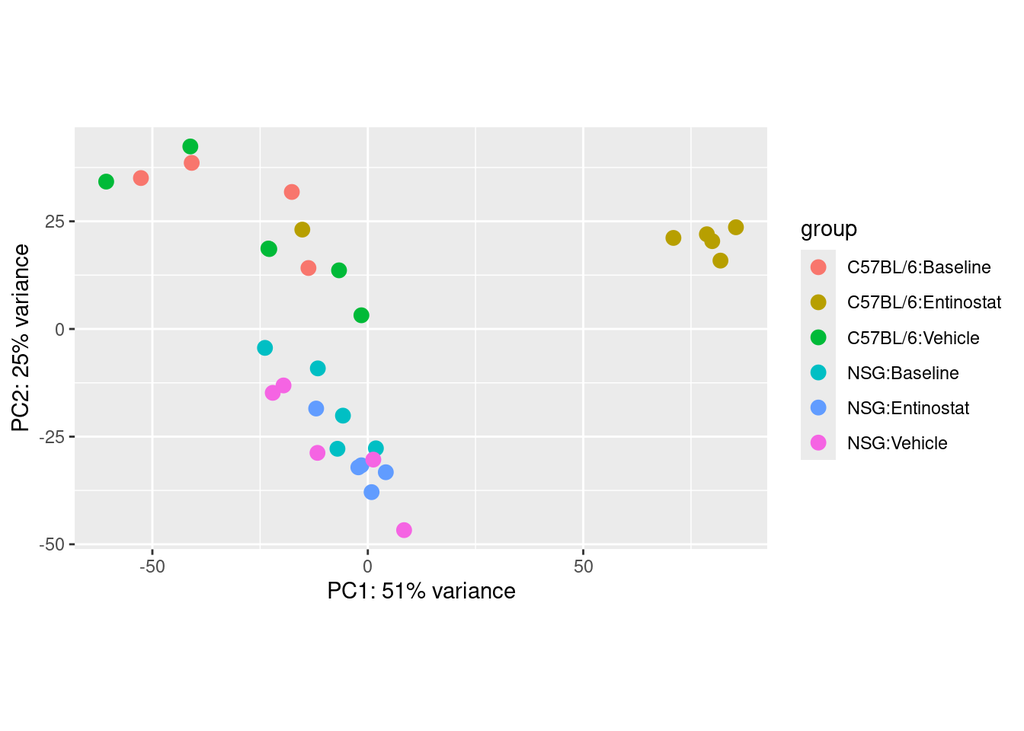

Principal component analyse (PCA) die de variantie van gen expressie weergeeft. Elk punt representeerd 1 sample kleurgecodeerd per groep.

```r
vsd <- vst(dds, blind=FALSE)
plotPCA(vsd, intgroup=c("strain", "treatment"))
```

Wat opvallend is in deze plot is dat C57BL/6:Entinostat als groep ver gescheiden ligt van de rest van de groepen. Op 1 punt na. Ook is zichtbaar dat er nog best wat spreiding is tussen de samples in groepen. Ook is er een duidelijke scheiding zichtbaar tussen de NSG en C57BL/6 groepen, waarbij alle samples van C57BL/6 boven de 0 van PC2 liggen, en de nsg onder de 0 van PC2.

Ook blijkt de entinostat niet veel invloed te hebben op de genexpressie bij de NSG groep, hoewel hier wel iets wat minder variantie zichtbaar is tussen de samples in de groep.

## Impact entinostat op nsg muis

#### 31-10-2024

In de literatuur staat dat entinostat immuun gerelateerde genen tot expressie zou moeten brengen. Wij zijn benieuwd naar of dit ook daadwerkelijk gebeurt. Wij willen dus gaan kijken naar de impact van entinostat op gen expressie bij een nsg muis. Dit gaan we doen door baseline (Tumor direct verwijderd uit de muis) te vergelijken met de vehicle (neutrale treatment zonder entinostat), en deze 2 ook nog los vergelijken met de entinostat treatment.

We gaan de dataset zo aanpassen dat deze alleen maar NSG data bevat.

```r
dds_nsg_subset <- dds[, c(nsg_Baseline,nsg_Entinostat, nsg_Vehicle)]
dds_nsg_subset <- DESeqDataSet(dds_nsg_subset, design = ~0 + treatment)


dds_nsg_subset <- DESeq(dds_nsg_subset)

head(dds_nsg_subset)
```

```
## class: DESeqDataSet
## dim: 6 15
## metadata(1): version
## assays(4): counts mu H cooks
## rownames(6): MissingGeneID gene-0610005C13Rik ... gene-0610009L18Rik
##   gene-0610010K14Rik
## rowData names(54): baseMean baseVar ... deviance maxCooks
## colnames(15): NSG_Baseline_r1 NSG_Baseline_r2 ... NSG_Vehicle_r4
##   NSG_Vehicle_r5
## colData names(7): Run source_name ... condition sizeFactor
```

Nu hebben we de resultaten van het vergelijken tussen de 3 groepen in de NSG muis. Ik ga eerst kijken naar het verschil tussen de baseline en vehicle. Zo kunnen we zien of het hebben van de blaaskanker de genexpressie ook veranderd

### Baseline vs Vehicle

```r
res_baseline_vehicle_nsg <- results(dds_nsg_subset, contrast = c("treatment", "Baseline", "Vehicle"))
summary(res_baseline_vehicle_nsg)
```

```
##
## out of 30958 with nonzero total read count
## adjusted p-value < 0.1
## LFC > 0 (up)       : 2498, 8.1%
## LFC < 0 (down)     : 2979, 9.6%
## outliers [1]       : 57, 0.18%
## low counts [2]     : 10600, 34%
## (mean count < 2)
## [1] see 'cooksCutoff' argument of ?results
## [2] see 'independentFiltering' argument of ?results
```

Hier is zichtbaar dat met een p-waarde van 0.1 er een up regulatie is van 8.1% en een down regulatie van 9.6%.

Ik ga met behulp van een vulcanoplot kijken naar welke genen statistisch significant veranderd zijn van expressie.

```r
deseq.volcano <- function(res, datasetName, v1, v2) {
  return(EnhancedVolcano(res, x = 'log2FoldChange', y = 'padj',
                         lab=rownames(res),
                         title = paste(datasetName, v1, "vs", v2),
                         subtitle = bquote(italic('FDR <= 0.05 and absolute FC >= 2')),
                         # Change text and icon sizes
                         labSize = 3, pointSize = 1.5, axisLabSize=10, titleLabSize=12,
                         subtitleLabSize=8, captionLabSize=10,
                         # Disable legend
                         legendPosition = "none",
                         # Set cutoffs
                         pCutoff = 0.05, FCcutoff = 2))
}
```

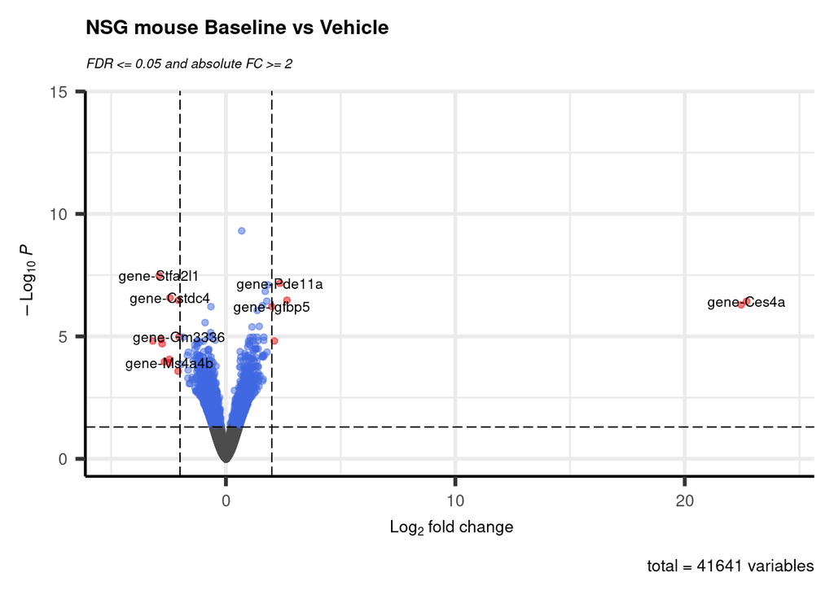

Deze grafiek geeft de relatie van statistische significantie (-log10 aagepaste p-waarde) en de log fold change (LFC) voor elk gen weer. De expressieniveaus tussen de baseline en vehicle groep worden vergeleken. Elk punt representeert een gen. Genen met een significante verandering van expressie (P-waarde <= 0.05 en LFC >= 2) worden weergegeven met een rode kleur. Genen met een statistische kleine verandering van expressie (P-waarde <= 0.05 en LFC < 2) worden weergegeven als blauwe punten. Niet statistisch significant genen worden in grijs weergegeven. De belangrijkste genen zijn gelabeled met de gennamen

```r
res_baseline_vehicle_nsg_lfc <- lfcShrink(dds_nsg_subset, contrast = c("treatment", "Baseline", "Vehicle"),
                                          res = res_baseline_vehicle_nsg, type = "ashr")
deseq.volcano(res = res_baseline_vehicle_nsg_lfc, datasetName = "NSG mouse", v1 = "Baseline", v2 = "Vehicle")
```

```r
nsg_res_baseline_vehicle_rmNa <- res_baseline_vehicle_nsg[!is.na(res_baseline_vehicle_nsg$log2FoldChange),]
gene_list <- nsg_res_baseline_vehicle_rmNa$log2FoldChange
names(gene_list) <- gsub("gene-", "",rownames(nsg_res_baseline_vehicle_rmNa))
gene_list <- sort(gene_list, decreasing = T)


gsea_res_nsg_baseline_vehicle <- gseGO(geneList = gene_list,
                  OrgDb = org.Mm.eg.db,
                  keyType = "SYMBOL",
                  ont = "BP",
                  pvalueCutoff = 0.05,
                  verbose = T)
top_go_terms <- head(gsea_res_nsg_baseline_vehicle[order(gsea_res_nsg_baseline_vehicle$p.adjust), ], 10)
```

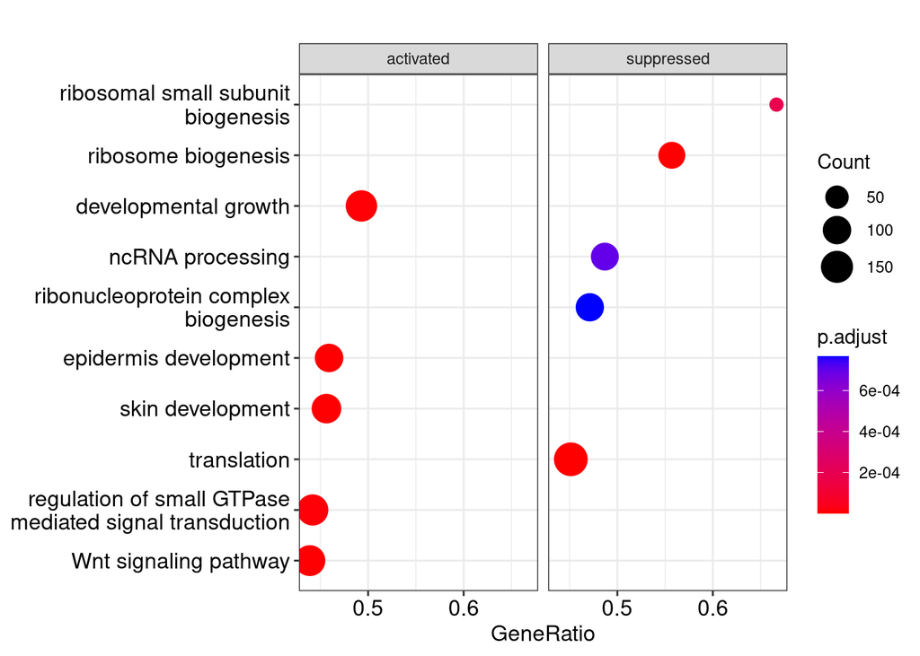

Deze grafiek geeft de resultaten van een Gene Set Enrichment Analysis (GSEA) op NSG muis model, waarin geactiveerde (links) en onderdrukte (rechts) biologische pathways worden getoond van de vehicle groep in vergelijking met de baseline. Op de y-as staan de pathways weergegeven. De x-as toont de genratio, ofwel het aandeel genen binnen deze pathway die tot differentieel tot expressie komt. De grote van het punt geeft weer wat het aantal betrokken genen is, de kleur geeft statistische significantie weer.

```r
dotplot(gsea_res_nsg_baseline_vehicle, split=".sign", showCategory = 5) + facet_grid(.~.sign)
```

### Baseline vs Entinostat

#### 02-11-2024

Nu gaan we kijken naar het verschil tussen de baseline en entinostat treatment

```r
res_baseline_entinostat_nsg <- results(dds_nsg_subset, contrast = c("treatment", "Baseline", "Entinostat"))
summary(res_baseline_entinostat_nsg)
```

```
##
## out of 30958 with nonzero total read count
## adjusted p-value < 0.1
## LFC > 0 (up)       : 1233, 4%
## LFC < 0 (down)     : 2132, 6.9%
## outliers [1]       : 57, 0.18%
## low counts [2]     : 10600, 34%
## (mean count < 2)
## [1] see 'cooksCutoff' argument of ?results
## [2] see 'independentFiltering' argument of ?results
```

Met een vulcano plot kan je weergeven hoe de logfold change is van een gen, maar ook de p-waarde hiervan.

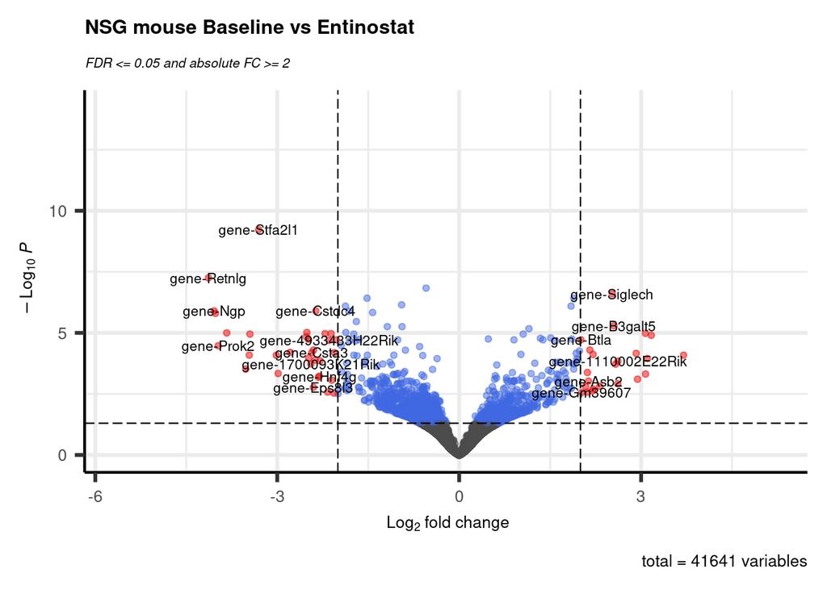

Deze grafiek geeft de relatie van statistische significantie (-log10 aagepaste p-waarde) en de log fold change (LFC) voor elk gen weer. De expressieniveaus tussen de baseline en entinostat groep worden vergeleken. Elk punt representeert een gen. Genen met een significante verandering van expressie (P-waarde <= 0.05 en LFC >= 2) worden weergegeven met een rode kleur. Genen met een statistische kleine verandering van expressie (P-waarde <= 0.05 en LFC < 2) worden weergegeven als blauwe punten. Niet statistisch significant genen worden in grijs weergegeven. De belangrijkste genen zijn gelabeled met de gennamen

```r
res_baseline_entinostat_nsg_lfc <- lfcShrink(dds_nsg_subset, contrast = c("treatment", "Baseline", "Vehicle"),
                                          res = res_baseline_entinostat_nsg, type = "ashr")
deseq.volcano(res = res_baseline_entinostat_nsg_lfc, datasetName = "NSG mouse", v1 = "Baseline", v2 = "Entinostat")
```

```r
res_baseline_entinostat_nsg_rmNa <- res_baseline_entinostat_nsg[!is.na(res_baseline_entinostat_nsg$log2FoldChange),]
gene_list <- res_baseline_entinostat_nsg_rmNa$log2FoldChange
names(gene_list) <- gsub("gene-", "",rownames(res_baseline_entinostat_nsg_rmNa))
gene_list <- sort(gene_list, decreasing = T)


gsea_res_nsg_baseline_entinostat <- gseGO(geneList = gene_list,
                  OrgDb = org.Mm.eg.db,
                  keyType = "SYMBOL",
                  ont = "BP",
                  pvalueCutoff = 0.05,
                  verbose = T)
```

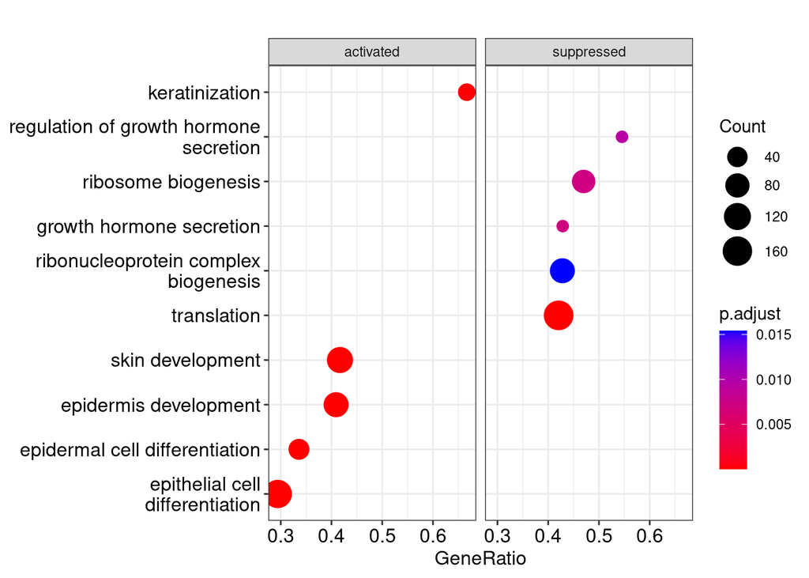

Deze grafiek geeft de resultaten van een Gene Set Enrichment Analysis (GSEA) op NSG muis model, waarin geactiveerde (links) en onderdrukte (rechts) biologische pathways worden getoond van de entinostat groep in vergelijking met de baseline. Op de y-as staan de pathways weergegeven. De x-as toont de genratio, ofwel het aandeel genen binnen deze pathway die tot differentieel tot expressie komt. De grote van het punt geeft weer wat het aantal betrokken genen is, de kleur geeft statistische significantie weer.

```r
dotplot(gsea_res_nsg_baseline_entinostat, split=".sign", showCategory = 5) + facet_grid(.~.sign)
```

#### 13-11-2024

```r
deseq.degs.logfc <- subset(res_baseline_entinostat_nsg, padj < 0.05, select = log2FoldChange)
pathview(gene.data=deseq.degs.logfc,
         pathway.id="04620", # Skin
         species="mmu"     # Organism key
)
```

## 30-11-2024

In de logboeken van Jannie en Jasper staat de verwerking van de andere muizen soort, graag had ik nog willen kijken naar de verschillen hiertussen. Maar ik wil deze module afsluiten, dus ik heb besloten dit niet te doen.